# R4DS Exercises 14-15

#### Load Packages

Code to load necessary packages

# Chapter 14

#### **14.2.5**

*1*

```r
?paste
?paste0
paste0(1:12, c("st", NA, "rd", rep("th", 9)))
```

```
 [1] "1st"  "2NA"  "3rd"  "4th"  "5th"  "6th"  "7th"  "8th"  "9th"
[10] "10th" "11th" "12th"
```

```r
str_c(1:12, c("st", NA, "rd", rep("th", 9)))
```

```
 [1] "1st"  NA     "3rd"  "4th"  "5th"  "6th"  "7th"  "8th"  "9th"
[10] "10th" "11th" "12th"
```

paste0 has a default separator of nothing (“”) - just like calling paste(…, sep = “”)  
Functions are equivalent to str_c in the stringr package  
Paste functions will combine a legitimate string & NA into a string, whereas Stringr overwrites the combination with NA  
ie: differences in 2nd value of code output from above

*2*  
sep is used to either combine strings explicitly passed to str_c or strings across vectors passed to str_c  
collapse is used to combine strings within a vector

*3*

```r
str_sub(x, len/2+1, len/2+1)
```

```
[1] "c"
```

If string length is even this function grabs the character at the ceiling(length) position

*4*

```r
?str_wrap
output <- "str_wrap is good for formatting strings into human readable scentences & paragraphs and adjusting things like width/indenting. You may want to use it when outputting long text strings into the consolse."
cat(str_wrap(output, width = 30), "\n")
```

```
str_wrap is good for
formatting strings into
human readable scentences
& paragraphs and adjusting
things like width/indenting.
You may want to use it when
outputting long text strings
into the consolse.
```

*5*  
str_trim will trim whitespace from the beginning/end of a string str_pad will add whitespace to beginning/end

*6*  
Create function to deal with comma separated strings

```r
oxfordComma(x)
```

```
[1] "a, b, c, and d"
```

#### **14.3.1.1**

*2*

```r
str_view("\"'\\", "\"'\\\\" )
```

*3*

```r
str_view(".x.y.z", "\\..\\..\\.." )
```

#### **14.3.2.1**

*1*

```r
str_view("$^$", "\\$\\^\\$")
```

*2*

```r
str_view(stringr::words, "^y", match = TRUE)
str_view(stringr::words, "x$", match = TRUE)
str_view(stringr::words, "^...$", match = TRUE)
str_view(stringr::words, "^.......", match = TRUE)
```

#### **14.3.3.1**

*1*

```r
str_view(stringr::words, "^[aeiou]", match = TRUE)
str_view(stringr::words, "^[^aeiou]+$", match = TRUE)
str_view(stringr::words, "[^e]ed$" , match = TRUE)
str_view(stringr::words, "(ing|ise)$" , match = TRUE)
```

*2*

```r
str_view(stringr::words, "[^c]ie" , match = TRUE)
```

*3*  
In dataset q is always followed by u

```r
str_view(stringr::words, "q[^u]", match = TRUE)
```

*4* Assume british english uses ‘our’ instead of ‘or’ (favor, color, etc…)

```r
str_view(stringr::words, "our", match = TRUE)
```

*5*

```r
str_view("828-275-4007", "\\d\\d\\d-\\d\\d\\d-\\d\\d\\d\\d", match = TRUE)
```

#### **14.4.2**

*1*

```r
#1
str_view(stringr::words, "(^x)|(x$)", match = TRUE)

word1 <- data.frame(words)
word1$endx <- str_detect(words, "x$")
word1$startx <- str_detect(words, "^x")
word1 %>%
  filter(endx == TRUE | startx == TRUE)

#2
str_view(stringr::words, "^[aeiou].*[^aeiou]$", match = TRUE)

word2 <- data.frame(words)
word2$startVowel <- str_detect(words, "^[aeiou]")
word2$endCons <- str_detect(words, "[^aeiou]$")
word2 %>%
  filter(startVowel == TRUE & endCons == TRUE)


#3

# Don't know the order the vowels will appear
# Can guaruntee 5 vowels - but not that they're unique amongst vowels
str_view(stringr::words, ".*[aeiou].*[aeiou].*[aeiou].*[aeiou].*", match = TRUE)
# For a single Regex have to have every possible permutation: 5! = 120 ()
# Found a permutation of all 120 combos on stack overflow (https://unix.stackexchange.com/questions/156134/grep-to-find-words-with-all-vowels)
str_view("eiousa", "a.*e.*i.*o.*u|a.*e.*i.*u.*o|a.*e.*o.*i.*u|a.*e.*o.*u.*i|a.*e.*u.*i.*o|a.*e.*u.*o.*i|a.*i.*e.*o.*u|a.*i.*e.*u.*o|a.*i.*o.*e.*u|a.*i.*o.*u.*e|a.*i.*u.*e.*o|a.*i.*u.*o.*e|a.*o.*e.*i.*u|a.*o.*e.*u.*i|a.*o.*i.*e.*u|a.*o.*i.*u.*e|a.*o.*u.*e.*i|a.*o.*u.*i.*e|a.*u.*e.*i.*o|a.*u.*e.*o.*i|a.*u.*i.*e.*o|a.*u.*i.*o.*e|a.*u.*o.*e.*i|a.*u.*o.*i.*e|e.*a.*i.*o.*u|e.*a.*i.*u.*o|e.*a.*o.*i.*u|e.*a.*o.*u.*i|e.*a.*u.*i.*o|e.*a.*u.*o.*i|e.*i.*a.*o.*u|e.*i.*a.*u.*o|e.*i.*o.*a.*u|e.*i.*o.*u.*a|e.*i.*u.*a.*o|e.*i.*u.*o.*a|e.*o.*a.*i.*u|e.*o.*a.*u.*i|e.*o.*i.*a.*u|e.*o.*i.*u.*a|e.*o.*u.*a.*i|e.*o.*u.*i.*a|e.*u.*a.*i.*o|e.*u.*a.*o.*i|e.*u.*i.*a.*o|e.*u.*i.*o.*a|e.*u.*o.*a.*i|e.*u.*o.*i.*a|i.*a.*e.*o.*u|i.*a.*e.*u.*o|i.*a.*o.*e.*u|i.*a.*o.*u.*e|i.*a.*u.*e.*o|i.*a.*u.*o.*e|i.*e.*a.*o.*u|i.*e.*a.*u.*o|i.*e.*o.*a.*u|i.*e.*o.*u.*a|i.*e.*u.*a.*o|i.*e.*u.*o.*a|i.*o.*a.*e.*u|i.*o.*a.*u.*e|i.*o.*e.*a.*u|i.*o.*e.*u.*a|i.*o.*u.*a.*e|i.*o.*u.*e.*a|i.*u.*a.*e.*o|i.*u.*a.*o.*e|i.*u.*e.*a.*o|i.*u.*e.*o.*a|i.*u.*o.*a.*e|i.*u.*o.*e.*a|o.*a.*e.*i.*u|o.*a.*e.*u.*i|o.*a.*i.*e.*u|o.*a.*i.*u.*e|o.*a.*u.*e.*i|o.*a.*u.*i.*e|o.*e.*a.*i.*u|o.*e.*a.*u.*i|o.*e.*i.*a.*u|o.*e.*i.*u.*a|o.*e.*u.*a.*i|o.*e.*u.*i.*a|o.*i.*a.*e.*u|o.*i.*a.*u.*e|o.*i.*e.*a.*u|o.*i.*e.*u.*a|o.*i.*u.*a.*e|o.*i.*u.*e.*a|o.*u.*a.*e.*i|o.*u.*a.*i.*e|o.*u.*e.*a.*i|o.*u.*e.*i.*a|o.*u.*i.*a.*e|o.*u.*i.*e.*a|u.*a.*e.*i.*o|u.*a.*e.*o.*i|u.*a.*i.*e.*o|u.*a.*i.*o.*e|u.*a.*o.*e.*i|u.*a.*o.*i.*e|u.*e.*a.*i.*o|u.*e.*a.*o.*i|u.*e.*i.*a.*o|u.*e.*i.*o.*a|u.*e.*o.*a.*i|u.*e.*o.*i.*a|u.*i.*a.*e.*o|u.*i.*a.*o.*e|u.*i.*e.*a.*o|u.*i.*e.*o.*a|u.*i.*o.*a.*e|u.*i.*o.*e.*a|u.*o.*a.*e.*i|u.*o.*a.*i.*e|u.*o.*e.*a.*i|u.*o.*e.*i.*a|u.*o.*i.*a.*e|u.*o.*i.*e.*a")

#str_detect helps simplify
word3 <- data.frame(words)
word3$a <- str_detect(words, "a")
word3$e <- str_detect(words, "e")
word3$i <- str_detect(words, "i")
word3$o <- str_detect(words, "o")
word3$u <- str_detect(words, "u")
word3 %>%
  filter(a == TRUE & e == TRUE & i == TRUE & o == TRUE & u == TRUE)
```

No words in the stringr::words data with all vowels

*2*

| words | length | vowels |
| --- | --- | --- |
| appropriate | 11 | 5 |
| associate | 9 | 5 |
| available | 9 | 5 |
| colleague | 9 | 5 |
| encourage | 9 | 5 |
| experience | 10 | 5 |
| individual | 10 | 5 |
| television | 10 | 5 |
| absolute | 8 | 4 |
| achieve | 7 | 4 |

[output cut: 970 more lines]

“appropriate”, “associate”, “available”, “colleague”, “encourage”, “experience”, “individual”, “television” all have 5 vowels (all tied for highest count)  
“a” has the highest vowel pct (100%), followed by “area” & “idea” at 75%

#### **14.4.6.1**

*1*

```r
"apples, pears, and bananas" %>%
  str_replace("and", "") %>%
  str_split(",")
```

*2*  
If a string has multiple spaces than str_split(" “) will bring in blank spaces as strings

*3*

```r
str_split("test string", "")
```

```
[[1]]
 [1] "t" "e" "s" "t" " " "s" "t" "r" "i" "n" "g"
```

Breaks the string into all individual characters

#### **15.4.1**

*1*  
There are 41 values for tvhour above 18 (which means people are only wathcing tv then sleeping - some values are even 24 hours which means no sleep) Should consider excluding outliers or unreasonable values (then mean could be a good value)

| n |
| --- |
| 41 |

*2*  
Year: principled  
Marital: arbitrary  
Age: principled  
Race: arbitrary  
rincome: principled  
partyid: arbitrary  
relig: arbitrary  
denom: arbitrary  
tvhours: principled

*3*  
The levels in the front get plotted as the bottom values (No answer and Don’t know were the other 2 levels in the front)

#### **15.5.1**

*1*  
Relatively flat trends over time looking at the bar graph below Small trend of more Independents & ‘others’ but no large trends in any direction

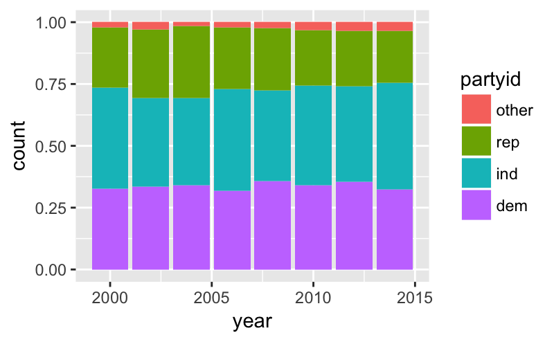

*2*  
Collapse rincome into smaller groups

| year | marital | age | race | rincome | partyid | relig | denom | tvhours |
| --- | --- | --- | --- | --- | --- | --- | --- | --- |
| 2000 | Never married | 26 | White | FiveKto10K | Ind,near rep | Protestant | Southern baptist | 12 |
| 2000 | Divorced | 48 | White | FiveKto10K | Not str republican | Protestant | Baptist-dk which | NA |
| 2000 | Widowed | 67 | White | unkown | Independent | Protestant | No denomination | 2 |
| 2000 | Never married | 39 | White | unkown | Ind,near rep | Orthodox-christian | Not applicable | 4 |
| 2000 | Divorced | 25 | White | unkown | Not str democrat | None | Not applicable | 1 |
| 2000 | Married | 25 | White | TenKOrMore | Strong democrat | Protestant | Southern baptist | NA |
| 2000 | Never married | 36 | White | TenKOrMore | Not str republican | Christian | Not applicable | 3 |
| 2000 | Divorced | 44 | White | FiveKto10K | Ind,near dem | Protestant | Lutheran-mo synod | NA |
| 2000 | Married | 44 | White | TenKOrMore | Not str democrat | Protestant | Other | 0 |
| 2000 | Married | 47 | White | TenKOrMore | Strong republican | Protestant | Southern baptist | 3 |

[output cut: 990 more lines]